# Final_Project

Prince Wang

12/7/2019

## Include data description(each variables meaning etc.) and what we are trying to do. We removed all 0 values and negative values for income since it is simply not reasonable to have 0 or negative values in income.

```r
library(alr4)
```

## First Look and plotting the data

```r
head(wh)
```

```
##   hours income age education child5 child13 child17 nonwhite owned
## 1  2000    350  26        12      0       1       0        0     1
## 2   390    241  29         8      0       1       1        0     1
## 3  1900    160  33        10      0       2       0        0     1
## 4     0     80  20         9      2       0       0        0     1
## 5  3177    456  33        12      0       2       0        0     1
## 6     0    390  22        12      2       0       0        0     1
##   mortgage occupation unemp
## 1        1       swcc     7
## 2        1      other     4
## 3        0       swcc     7
## 4        1      other     7
## 5        1       swcc     7
## 6        1      other     7
```

```r
summary(wh)
```

```
##      hours          income            age          education
##  Min.   :   0   Min.   :   1.0   Min.   :18.00   Min.   : 0.00
##  1st Qu.:   0   1st Qu.: 148.5   1st Qu.:28.00   1st Qu.:12.00
##  Median :1300   Median : 250.0   Median :34.00   Median :12.00
##  Mean   :1132   Mean   : 298.7   Mean   :36.82   Mean   :12.55
##  3rd Qu.:1944   3rd Qu.: 370.0   3rd Qu.:44.00   3rd Qu.:14.00
##  Max.   :5840   Max.   :7220.0   Max.   :64.00   Max.   :17.00
##      child5          child13         child17          nonwhite
##  Min.   :0.0000   Min.   :0.000   Min.   :0.0000   Min.   :0.0000
##  1st Qu.:0.0000   1st Qu.:0.000   1st Qu.:0.0000   1st Qu.:0.0000
##  Median :0.0000   Median :0.000   Median :0.0000   Median :0.0000
##  Mean   :0.5073   Mean   :0.562   Mean   :0.2153   Mean   :0.2947
##  3rd Qu.:1.0000   3rd Qu.:1.000   3rd Qu.:0.0000   3rd Qu.:1.0000
##  Max.   :4.0000   Max.   :5.000   Max.   :6.0000   Max.   :1.0000
##      owned          mortgage      occupation       unemp
##  Min.   :0.000   Min.   :0.0000   fr   :  82   Min.   : 1.000
##  1st Qu.:0.000   1st Qu.:0.0000   mp   : 960   1st Qu.: 4.000
##  Median :1.000   Median :1.0000   other:1301   Median : 5.000
##  Mean   :0.683   Mean   :0.5299   swcc :1020   Mean   : 5.635
##  3rd Qu.:1.000   3rd Qu.:1.0000                3rd Qu.: 7.000
##  Max.   :1.000   Max.   :1.0000                Max.   :30.000
```

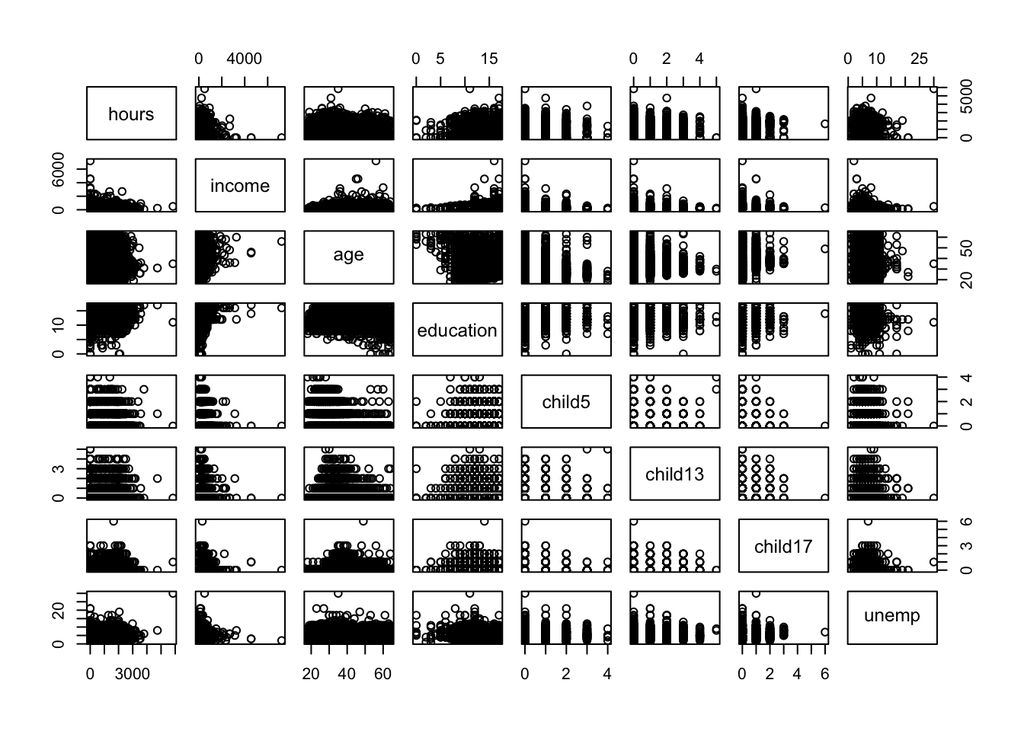

```r
plot(~ hours + income + age + education + child5 + child13 + child17 + unemp, data = wh)
```

## From the summary of our data set, we can first get a sense of different predictors and response. We set the “working hours” as response and identified seven numerical predictors and four categorical predictors. In terms of the numerical ones, they are husband’s income, wife’s age, wife’s education years, and three numerical predictor related to the number of children in different age group, 0-5 years old, 6-13 years old and 14-17 years old. As for the categorical predictor, we have “0” representing white wife and “1” representing nonwhite wife. “Occupation” to classify the husband’s job and “Owned” and “Mortgage” to describe their housing condition.

## From the plot graph we can easily find that working hours have some relationship with husband’s income and are heavily affected by the number of children,especially younger children. We’ll get into more details later by quantifying our data and building up our regression model.

## Building an intial model using all variables, check the residuals, transform and check on which variable can be removed.

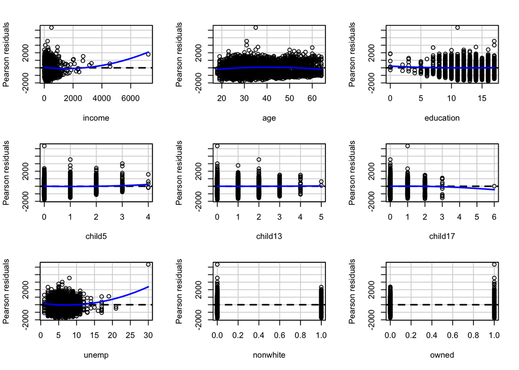

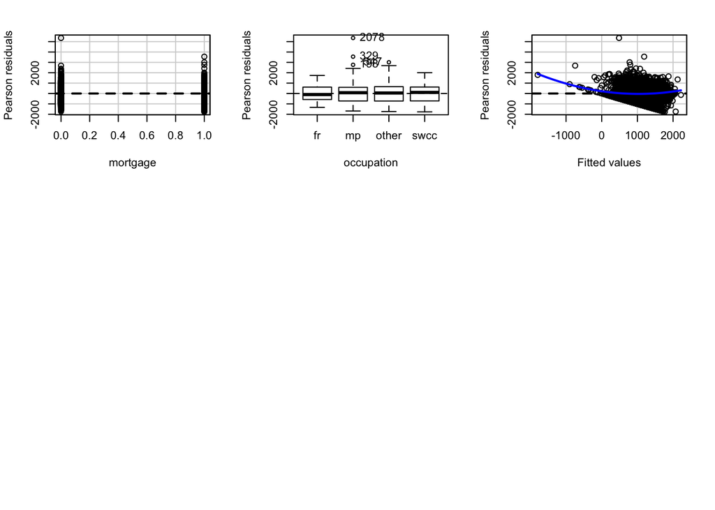

```r
fit1 <-lm(hours ~ income + age + education + child5 + child13 + child17 + unemp + nonwhite + owned + mortgage + occupation, data = wh)
residualPlots(fit1, tests =  FALSE)
```

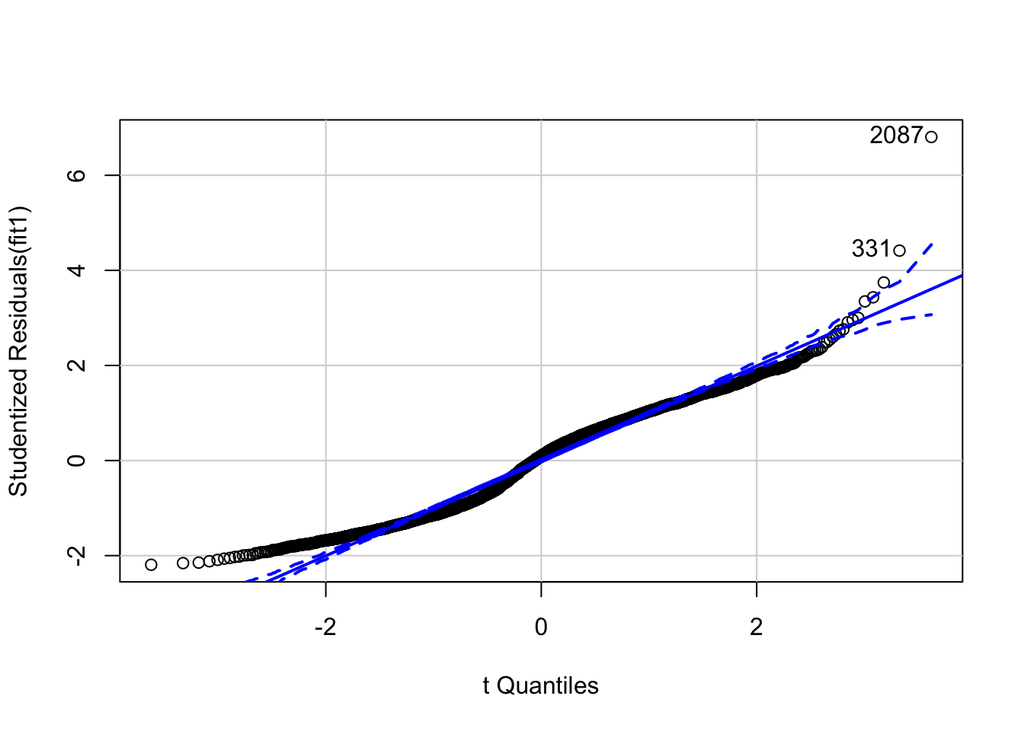

```
##  331 2087
##  329 2078
```

```r
qqPlot(fit1)
```

## From the residual plot,we can find that these predictors seem all useful to our model because the lines are pretty flat when the predictors are within normal range. For example, in the income residual plot, the line is flat when income is not very large. This means for the majority of families, the husband earns more, the wife will have less working hours. Only a few data we collected have very large income and they affect our residual plot very much, but we don’t need to focus on that minority too much. Same logic to unemployment rate predictor, when the unemployment rate is very high, it will affect our residual plot very much, but when it’s within normal range, we found the line is pretty flat, which means our model is not violating any assumptions. In terms of the children factor, age and education factor, the lines are flat enough.

# The residuals look good so we can move on and build our initial model with all variables

```r
lm0 <-lm(hours ~ income + age + education + child5 + child13 + child17 + unemp + nonwhite + owned + mortgage + occupation, data = wh)
summary(lm0)
```

```
##
## Call:
## lm(formula = hours ~ income + age + education + child5 + child13 +
##     child17 + unemp + nonwhite + owned + mortgage + occupation,
##     data = wh)
##
## Residuals:
##     Min      1Q  Median      3Q     Max
## -1768.7  -721.8    77.5   630.6  5354.6
##
## Coefficients:
##                   Estimate Std. Error t value Pr(>|t|)
## (Intercept)     1173.37671  144.17253   8.139 5.57e-16 ***
## income            -0.43037    0.05478  -7.857 5.27e-15 ***
## age              -19.62523    1.57907 -12.428  < 2e-16 ***
## education         66.07011    6.60715  10.000  < 2e-16 ***
## child5          -385.25075   20.55656 -18.741  < 2e-16 ***
## child13         -125.08106   16.76743  -7.460 1.10e-13 ***
## child17           39.61039   28.33250   1.398  0.16219
## unemp            -26.23747    6.18397  -4.243 2.27e-05 ***
## nonwhite         137.97099   32.80602   4.206 2.67e-05 ***
## owned             11.30635   49.21827   0.230  0.81832
## mortgage         211.50116   43.73854   4.836 1.39e-06 ***
## occupationmp     222.70127   95.12376   2.341  0.01928 *
## occupationother  213.49502   92.46896   2.309  0.02101 *
## occupationswcc   260.16889   93.37452   2.786  0.00536 **
## ---
## Signif. codes:  0 '***' 0.001 '**' 0.01 '*' 0.05 '.' 0.1 ' ' 1
##
## Residual standard error: 808.3 on 3349 degrees of freedom
## Multiple R-squared:  0.1832, Adjusted R-squared:   0.18
## F-statistic: 57.78 on 13 and 3349 DF,  p-value: < 2.2e-16
```

```r
# Firstly, we want to transform the predictors, and since the predictors are not strictly positive, we use yj method
summary(powerTransform(cbind(income, age, education, unemp, child5, child13, child17) ~ 1, data = wh, family = "yjPower"))
```

```
## yjPower Transformations to Multinormality
##           Est Power Rounded Pwr Wald Lwr Bnd Wald Upr Bnd
## income       0.2177        0.22       0.1919       0.2435
## age         -0.2891       -0.33      -0.4006      -0.1776
## education    1.4313        1.43       1.3213       1.5412
## unemp        0.0887        0.09       0.0131       0.1644
## child5      -2.1062       -2.00      -2.2392      -1.9733
## child13     -1.9693       -2.00      -2.0934      -1.8451
## child17     -7.0478       -7.05      -7.3065      -6.7891
##
##  Likelihood ratio test that all transformation parameters are equal to 0
##                                        LRT df       pval
## LR test, lambda = (0 0 0 0 0 0 0) 9397.618  7 < 2.22e-16
```

```r
# since there is 0s in child5, child13, child17, we cannot use the powertransformation of negative number.
##I added 1 to each of the predictors, based on the formula of Yeo-Johnson
lm1 <- lm(hours ~ I((income)^(0.22))+ I((age)^(-0.33)) + I((education)^1.43) + nonwhite + I(unemp^0.09) + mortgage + occupation+child5+child13+child17, data = wh)
summary(lm0)
```

```
##
## Call:
## lm(formula = hours ~ income + age + education + child5 + child13 +
##     child17 + unemp + nonwhite + owned + mortgage + occupation,
##     data = wh)
##
## Residuals:
##     Min      1Q  Median      3Q     Max
## -1768.7  -721.8    77.5   630.6  5354.6
##
## Coefficients:
##                   Estimate Std. Error t value Pr(>|t|)
## (Intercept)     1173.37671  144.17253   8.139 5.57e-16 ***
## income            -0.43037    0.05478  -7.857 5.27e-15 ***
## age              -19.62523    1.57907 -12.428  < 2e-16 ***
## education         66.07011    6.60715  10.000  < 2e-16 ***
## child5          -385.25075   20.55656 -18.741  < 2e-16 ***
## child13         -125.08106   16.76743  -7.460 1.10e-13 ***
## child17           39.61039   28.33250   1.398  0.16219
## unemp            -26.23747    6.18397  -4.243 2.27e-05 ***
## nonwhite         137.97099   32.80602   4.206 2.67e-05 ***
## owned             11.30635   49.21827   0.230  0.81832
## mortgage         211.50116   43.73854   4.836 1.39e-06 ***
## occupationmp     222.70127   95.12376   2.341  0.01928 *
## occupationother  213.49502   92.46896   2.309  0.02101 *
## occupationswcc   260.16889   93.37452   2.786  0.00536 **
## ---
## Signif. codes:  0 '***' 0.001 '**' 0.01 '*' 0.05 '.' 0.1 ' ' 1
##
## Residual standard error: 808.3 on 3349 degrees of freedom
## Multiple R-squared:  0.1832, Adjusted R-squared:   0.18
## F-statistic: 57.78 on 13 and 3349 DF,  p-value: < 2.2e-16
```

```r
summary(lm1)
```

```
##
## Call:
## lm(formula = hours ~ I((income)^(0.22)) + I((age)^(-0.33)) +
##     I((education)^1.43) + nonwhite + I(unemp^0.09) + mortgage +
##     occupation + child5 + child13 + child17, data = wh)
##
## Residuals:
##     Min      1Q  Median      3Q     Max
## -1855.2  -720.3    62.2   635.8  5169.6
##
## Coefficients:
##                      Estimate Std. Error t value Pr(>|t|)
## (Intercept)          1004.214    454.907   2.208 0.027346 *
## I((income)^(0.22))   -269.106     31.337  -8.588  < 2e-16 ***
## I((age)^(-0.33))     6249.184    546.122  11.443  < 2e-16 ***
## I((education)^1.43)    17.863      1.596  11.191  < 2e-16 ***
## nonwhite              124.659     32.957   3.783 0.000158 ***
## I(unemp^0.09)       -1543.487    334.901  -4.609  4.2e-06 ***
## mortgage              268.007     30.644   8.746  < 2e-16 ***
## occupationmp          271.301     96.037   2.825 0.004757 **
## occupationother       227.356     92.909   2.447 0.014453 *
## occupationswcc        314.718     94.134   3.343 0.000837 ***
## child5               -373.239     20.637 -18.086  < 2e-16 ***
## child13              -101.886     16.671  -6.112  1.1e-09 ***
## child17                62.039     28.553   2.173 0.029869 *
## ---
## Signif. codes:  0 '***' 0.001 '**' 0.01 '*' 0.05 '.' 0.1 ' ' 1
##
## Residual standard error: 811.8 on 3350 degrees of freedom
## Multiple R-squared:  0.176,  Adjusted R-squared:  0.173
## F-statistic: 59.62 on 12 and 3350 DF,  p-value: < 2.2e-16
```

```r
# Since after the transformation, the R-squared goes lower, we decided not to take the transformation for the predictors

# Because there is 0 hour for women working hour, we cannot applyed the Box-Cox method, we used YJ instead.

p1 <- powerTransform(hours ~ income + age + education + child5 + child13 + child17 + unemp + nonwhite + owned + mortgage + occupation, data = wh, family = "yjPower")
summary(p1)
```

```
## yjPower Transformation to Normality
##    Est Power Rounded Pwr Wald Lwr Bnd Wald Upr Bnd
## Y1    0.3293        0.33       0.3124       0.3462
##
##  Likelihood ratio test that transformation parameter is equal to 0
##                            LRT df       pval
## LR test, lambda = (0) 1651.286  1 < 2.22e-16
```

```r
lm2 <- lm(I(hours^0.33) ~ income + age + education + child5 + child13 + child17 + unemp + nonwhite + owned + mortgage + occupation, data = wh)
summary(lm0)
```

```
##
## Call:
## lm(formula = hours ~ income + age + education + child5 + child13 +
##     child17 + unemp + nonwhite + owned + mortgage + occupation,
##     data = wh)
##
## Residuals:
##     Min      1Q  Median      3Q     Max
## -1768.7  -721.8    77.5   630.6  5354.6
##
## Coefficients:
##                   Estimate Std. Error t value Pr(>|t|)
## (Intercept)     1173.37671  144.17253   8.139 5.57e-16 ***
## income            -0.43037    0.05478  -7.857 5.27e-15 ***
## age              -19.62523    1.57907 -12.428  < 2e-16 ***
## education         66.07011    6.60715  10.000  < 2e-16 ***
## child5          -385.25075   20.55656 -18.741  < 2e-16 ***
## child13         -125.08106   16.76743  -7.460 1.10e-13 ***
## child17           39.61039   28.33250   1.398  0.16219
## unemp            -26.23747    6.18397  -4.243 2.27e-05 ***
## nonwhite         137.97099   32.80602   4.206 2.67e-05 ***
## owned             11.30635   49.21827   0.230  0.81832
## mortgage         211.50116   43.73854   4.836 1.39e-06 ***
## occupationmp     222.70127   95.12376   2.341  0.01928 *
## occupationother  213.49502   92.46896   2.309  0.02101 *
## occupationswcc   260.16889   93.37452   2.786  0.00536 **
## ---
## Signif. codes:  0 '***' 0.001 '**' 0.01 '*' 0.05 '.' 0.1 ' ' 1
##
## Residual standard error: 808.3 on 3349 degrees of freedom
## Multiple R-squared:  0.1832, Adjusted R-squared:   0.18
## F-statistic: 57.78 on 13 and 3349 DF,  p-value: < 2.2e-16
```

```r
summary(lm2)
```

```
##
## Call:
## lm(formula = I(hours^0.33) ~ income + age + education + child5 +
##     child13 + child17 + unemp + nonwhite + owned + mortgage +
##     occupation, data = wh)
##
## Residuals:
##     Min      1Q  Median      3Q     Max
## -11.686  -4.019   1.333   3.451  15.265
##
## Coefficients:
##                   Estimate Std. Error t value Pr(>|t|)
## (Intercept)      8.4474379  0.8302482  10.175  < 2e-16 ***
## income          -0.0025463  0.0003154  -8.072 9.55e-16 ***
## age             -0.1202689  0.0090934 -13.226  < 2e-16 ***
## education        0.4192768  0.0380487  11.019  < 2e-16 ***
## child5          -2.1025377  0.1183793 -17.761  < 2e-16 ***
## child13         -0.6230938  0.0965588  -6.453 1.25e-10 ***
## child17          0.3187077  0.1631587   1.953   0.0509 .
## unemp           -0.1888640  0.0356117  -5.303 1.21e-07 ***
## nonwhite         0.7908016  0.1889205   4.186 2.91e-05 ***
## owned           -0.1125304  0.2834339  -0.397   0.6914
## mortgage         1.2445771  0.2518777   4.941 8.15e-07 ***
## occupationmp     1.0525457  0.5477904   1.921   0.0548 .
## occupationother  0.9664249  0.5325022   1.815   0.0696 .
## occupationswcc   1.3024263  0.5377171   2.422   0.0155 *
## ---
## Signif. codes:  0 '***' 0.001 '**' 0.01 '*' 0.05 '.' 0.1 ' ' 1
##
## Residual standard error: 4.655 on 3349 degrees of freedom
## Multiple R-squared:  0.1903, Adjusted R-squared:  0.1871
## F-statistic: 60.54 on 13 and 3349 DF,  p-value: < 2.2e-16
```

```r
# since the R-squared goes up by almost 0.01, we decided to use the powertransformation on the response


Anova(lm2)
```

```
## Anova Table (Type II tests)
##
## Response: I(hours^0.33)
##            Sum Sq   Df  F value    Pr(>F)
## income       1412    1  65.1573 9.546e-16 ***
## age          3790    1 174.9261 < 2.2e-16 ***
## education    2631    1 121.4289 < 2.2e-16 ***
## child5       6835    1 315.4539 < 2.2e-16 ***
## child13       902    1  41.6412 1.254e-10 ***
## child17        83    1   3.8156   0.05086 .
## unemp         609    1  28.1263 1.210e-07 ***
## nonwhite      380    1  17.5217 2.913e-05 ***
## owned           3    1   0.1576   0.69137
## mortgage      529    1  24.4154 8.145e-07 ***
## occupation    159    3   2.4489   0.06182 .
## Residuals   72563 3349
## ---
## Signif. codes:  0 '***' 0.001 '**' 0.01 '*' 0.05 '.' 0.1 ' ' 1
```

```r
# Based on F values and P value, we can accept the NH for child17, owned and occupation.

lm3 <- lm(I(hours^0.33) ~ income + age + education + child5 + child13 + unemp + nonwhite + mortgage, data = wh)
summary(lm3)
```

```
##
## Call:
## lm(formula = I(hours^0.33) ~ income + age + education + child5 +
##     child13 + unemp + nonwhite + mortgage, data = wh)
##
## Residuals:
##     Min      1Q  Median      3Q     Max
## -11.546  -4.068   1.329   3.468  15.254
##
## Coefficients:
##               Estimate Std. Error t value Pr(>|t|)
## (Intercept)  9.6372416  0.6609845  14.580  < 2e-16 ***
## income      -0.0024870  0.0003079  -8.078 9.10e-16 ***
## age         -0.1235581  0.0082897 -14.905  < 2e-16 ***
## education    0.4182099  0.0363712  11.498  < 2e-16 ***
## child5      -2.1480255  0.1170520 -18.351  < 2e-16 ***
## child13     -0.6080272  0.0961530  -6.324 2.89e-10 ***
## unemp       -0.1887942  0.0355083  -5.317 1.12e-07 ***
## nonwhite     0.8230613  0.1848509   4.453 8.76e-06 ***
## mortgage     1.2309750  0.1694671   7.264 4.66e-13 ***
## ---
## Signif. codes:  0 '***' 0.001 '**' 0.01 '*' 0.05 '.' 0.1 ' ' 1
##
## Residual standard error: 4.659 on 3354 degrees of freedom
## Multiple R-squared:  0.1876, Adjusted R-squared:  0.1857
## F-statistic: 96.82 on 8 and 3354 DF,  p-value: < 2.2e-16
```

```r
Anova(lm3)
```

```
## Anova Table (Type II tests)
##
## Response: I(hours^0.33)
##           Sum Sq   Df F value    Pr(>F)
## income      1416    1  65.253 9.097e-16 ***
## age         4822    1 222.158 < 2.2e-16 ***
## education   2870    1 132.213 < 2.2e-16 ***
## child5      7310    1 336.761 < 2.2e-16 ***
## child13      868    1  39.987 2.894e-10 ***
## unemp        614    1  28.270 1.125e-07 ***
## nonwhite     430    1  19.825 8.761e-06 ***
## mortgage    1145    1  52.763 4.658e-13 ***
## Residuals  72802 3354
## ---
## Signif. codes:  0 '***' 0.001 '**' 0.01 '*' 0.05 '.' 0.1 ' ' 1
```

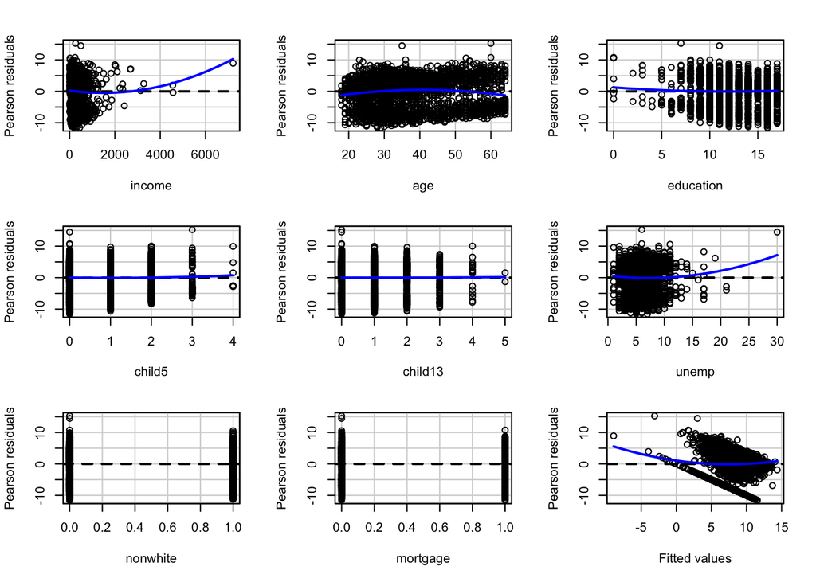

```
##            Test stat Pr(>|Test stat|)
## income        3.0881         0.002031 **
## age          -6.2775        3.882e-10 ***
## education     1.2552         0.209499
## child5        0.8377         0.402283
## child13       0.1372         0.890858
## unemp         2.3341         0.019652 *
## nonwhite     -0.7252         0.468368
## mortgage      1.4407         0.149752
## Tukey test    2.5951         0.009457 **
## ---
## Signif. codes:  0 '***' 0.001 '**' 0.01 '*' 0.05 '.' 0.1 ' ' 1
```

```r
residualPlots(lm3)
```

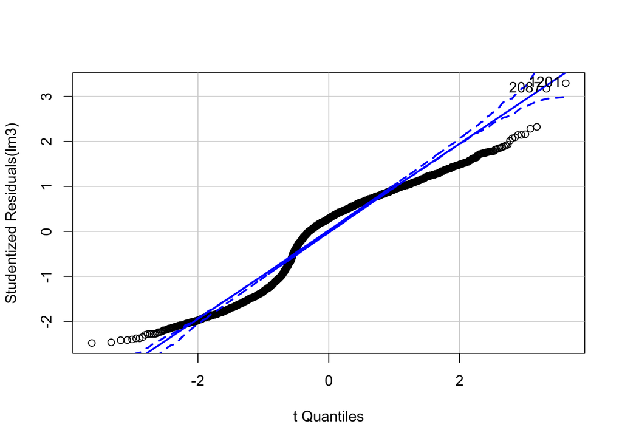

```
## 1201 2087
## 1195 2078
```

```r
qqPlot(lm3)
```

```r
# the F-test suggests all predictors can reject so the next step is to apply transformation
```

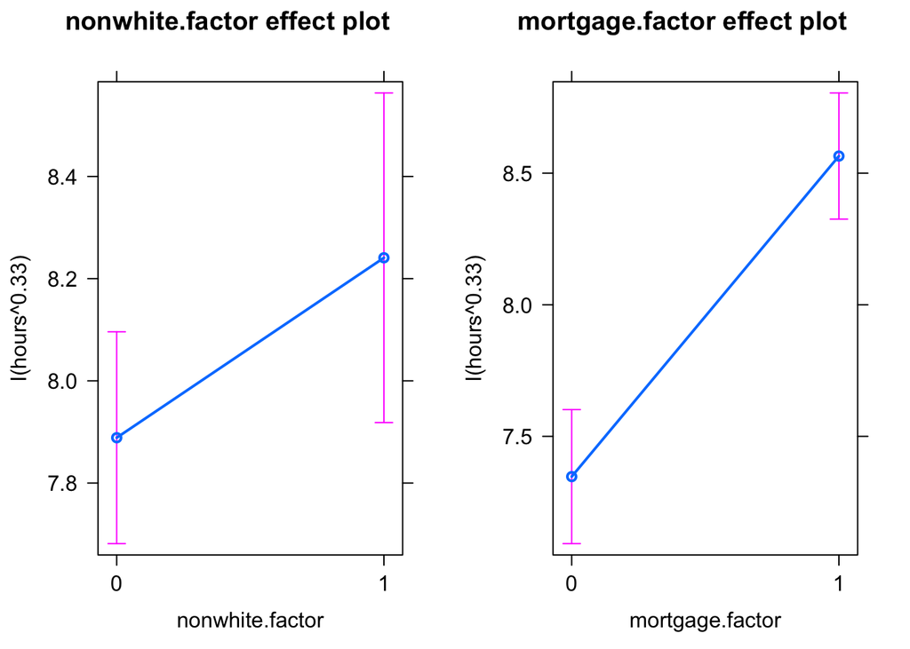

```r
#  effect plots
wh$nonwhite.factor <- factor(wh$nonwhite)
wh$mortgage.factor <- factor(wh$mortgage)
l0 <- lm(I(hours^0.33) ~ nonwhite.factor+mortgage.factor, data = wh)
l1 <- lm(I(hours^0.33) ~ child5+child13+child17, data = wh)
l2 <- lm(I(hours^0.33) ~ income+age+education+unemp, data = wh)
plot(allEffects(l0))
```

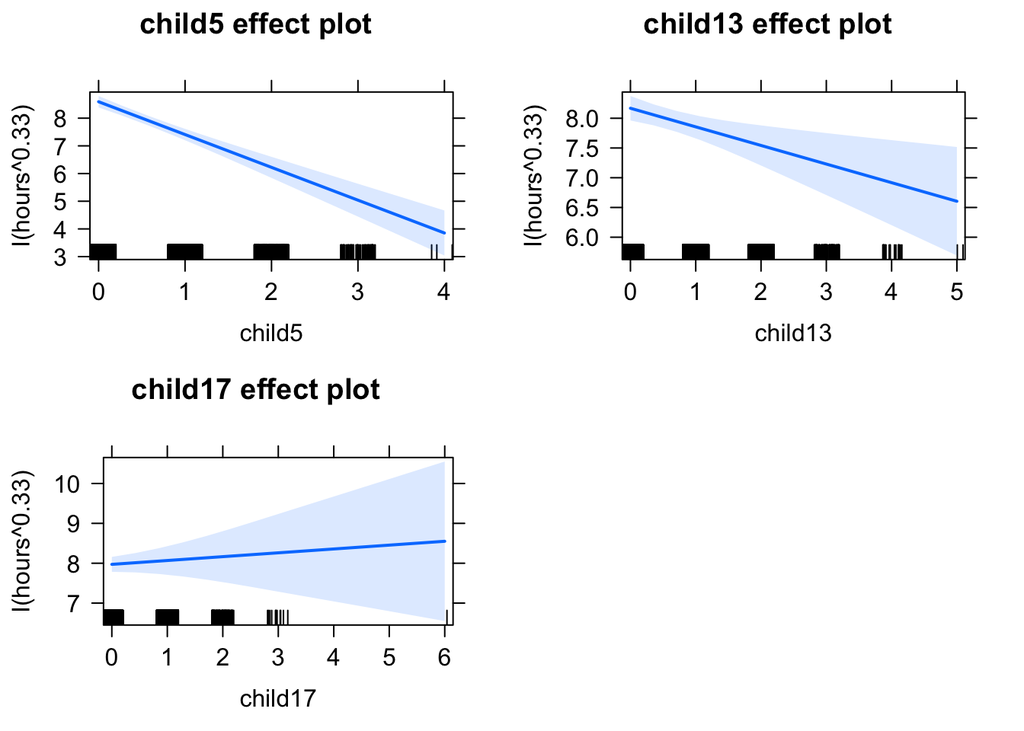

```r
plot(allEffects(l1))
```

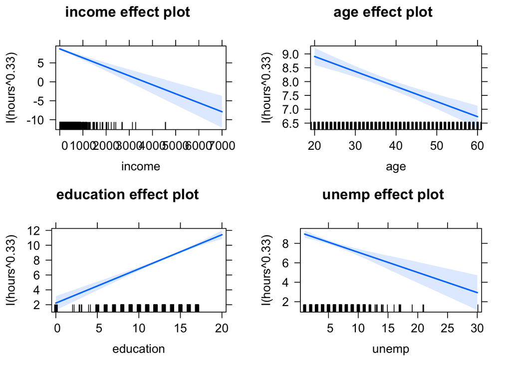

```r
plot(allEffects(l2))
```

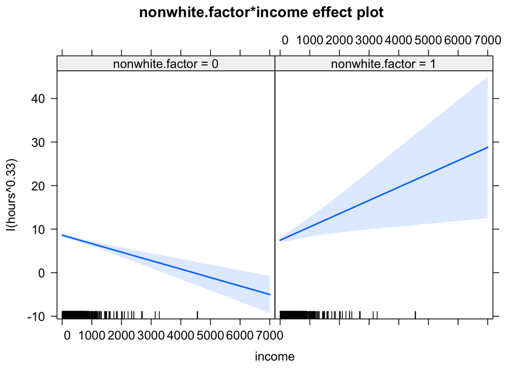

```r
l3 <- lm(I(hours^0.33) ~ nonwhite.factor*income,data=wh)
plot(allEffects(l3))
```

## We did effect plots here because we want to classify the main effect and interations on the response. First, we plot the two categorical factors, which is nonwhite and mortgage. Generally speaking, nonwhite has longer working hours than white. For families who have mortgage, the wife will work much longer than no mortgage family. These foundings do emphasize people’s color and housing situation have influence on the wife’s working hours.

## Same logic to the children age factor, we found children number has signicant effect on the wife’s working hours, especially children below 13 years old. More young children a family has, the less working hours of the wilfe. This finding makes us notice the working wife’s situation and the low fertility problem in the current society.

## The most interesting finding is from plot l3, we are curious about the nonwhite and income interation to the response. As is shown in the plot graph, nonwhite and white have opposite react to higher income. For nonwhite wife, the higher their husband earn, the longer working hours they have, but for white wife, they will work shorter time if their husbands have a high income. Are there any phychological reasons behind it?

## Segment data into model part and test part and applied the model. Since we want to test how our model works, we simply segment the data into two parts, 80% for model buidling and 20% for testing.

```r
nrow(wh)*0.8
```

```
## [1] 2690.4
```

```r
data1 <- wh[c(1:2690),]
data2 <- wh[c(2691:3363),]

lm4 <- lm(I(hours^0.33) ~ income + age + education + child5 + child13 + nonwhite + unemp + mortgage, data = data1)
summary(lm4)
```

```
##
## Call:
## lm(formula = I(hours^0.33) ~ income + age + education + child5 +
##     child13 + nonwhite + unemp + mortgage, data = data1)
##
## Residuals:
##     Min      1Q  Median      3Q     Max
## -11.599  -4.283   1.383   3.484  15.249
##
## Coefficients:
##               Estimate Std. Error t value Pr(>|t|)
## (Intercept) 10.0840784  0.7447505  13.540  < 2e-16 ***
## income      -0.0024629  0.0003203  -7.689 2.07e-14 ***
## age         -0.1271900  0.0092199 -13.795  < 2e-16 ***
## education    0.3881774  0.0415145   9.350  < 2e-16 ***
## child5      -2.1921335  0.1351329 -16.222  < 2e-16 ***
## child13     -0.6644820  0.1096161  -6.062 1.53e-09 ***
## nonwhite     0.6589092  0.2302034   2.862  0.00424 **
## unemp       -0.1700516  0.0407700  -4.171 3.13e-05 ***
## mortgage     1.2812818  0.1898095   6.750 1.80e-11 ***
## ---
## Signif. codes:  0 '***' 0.001 '**' 0.01 '*' 0.05 '.' 0.1 ' ' 1
##
## Residual standard error: 4.677 on 2681 degrees of freedom
## Multiple R-squared:  0.1796, Adjusted R-squared:  0.1772
## F-statistic: 73.38 on 8 and 2681 DF,  p-value: < 2.2e-16
```

```r
y <- data2[,"hours"]
y1 <- y^0.33
y1.bar <- mean(y1)
y.hat <- predict(lm4, data2)

e.hat <- y1 - y.hat
n <- nrow(data2)
df <- n - 9
RSS <- sum(e.hat^2)
RSquared <- 1 - RSS/sum((y1-y1.bar)^2)
print(RSquared)
```

```
## [1] 0.2161962
```

## We applied our model to predit the working hours of wife given specific predictors and got R squared 22%, which means our model can inteprete 22% of reason behind the working hours of wife.

## Discovering active predictors using AIC

```r
lm5 <- lm(I(hours^0.33) ~ income, data = wh)
m.forward <- step(lm5, scope = list(lower = I(hours^0.33) ~ income, upper = I(hours^0.33) ~ income + age + education + child5 + child13 + nonwhite + unemp + mortgage ), direction = "forward", k = 2, trace = 1)
```

```
## Start:  AIC=11017.23
## I(hours^0.33) ~ income
##
##             Df Sum of Sq   RSS   AIC
## + education  1    5390.8 83522 10809
## + child5     1    3096.8 85816 10900
## + age        1    2535.1 86378 10922
## + mortgage   1    1677.9 87235 10955
## + unemp      1    1096.0 87817 10978
## + child13    1     234.4 88678 11010
## <none>                   88913 11017
## + nonwhite   1       3.9 88909 11019
##
## Step:  AIC=10808.89
## I(hours^0.33) ~ income + education
##
##            Df Sum of Sq   RSS   AIC
## + child5    1    3803.4 79719 10654
## + age       1    1110.2 82412 10766
## + mortgage  1     906.2 82616 10774
## + unemp     1     705.1 82817 10782
## + child13   1     224.8 83297 10802
## + nonwhite  1      70.4 83452 10808
## <none>                  83522 10809
##
## Step:  AIC=10654.15
## I(hours^0.33) ~ income + education + child5
##
##            Df Sum of Sq   RSS   AIC
## + age       1    4177.1 75542 10475
## + mortgage  1     839.9 78879 10620
## + unemp     1     643.3 79075 10629
## + child13   1     233.8 79485 10646
## + nonwhite  1     185.2 79534 10648
## <none>                  79719 10654
##
## Step:  AIC=10475.15
## I(hours^0.33) ~ income + education + child5 + age
##
##            Df Sum of Sq   RSS   AIC
```

[output cut: 20 more lines]

```
## + unemp     1    561.21 73233 10377
## + nonwhite  1    377.92 73416 10385
## <none>                  73794 10400
##
## Step:  AIC=10376.76
## I(hours^0.33) ~ income + education + child5 + age + mortgage +
##     child13 + unemp
##
##            Df Sum of Sq   RSS   AIC
## + nonwhite  1    430.33 72802 10359
## <none>                  73233 10377
##
## Step:  AIC=10358.94
## I(hours^0.33) ~ income + education + child5 + age + mortgage +
##     child13 + unemp + nonwhite
```

```r
m.back <- step(lm3, scope = list(lower = I(hours^0.33) ~ income, upper = I(hours^0.33) ~ income + age + education + child5 + child13 + nonwhite + unemp + mortgage ), direction = "backward", k = 2, trace = 1)
```

```
## Start:  AIC=10358.94
## I(hours^0.33) ~ income + age + education + child5 + child13 +
##     unemp + nonwhite + mortgage
##
##             Df Sum of Sq   RSS   AIC
## <none>                   72802 10359
## - nonwhite   1     430.3 73233 10377
## - unemp      1     613.6 73416 10385
## - child13    1     868.0 73670 10397
## - mortgage   1    1145.3 73948 10409
## - education  1    2869.8 75672 10487
## - age        1    4822.2 77625 10573
## - child5     1    7309.8 80112 10679
```

```r
summary(m.back)
```

```
##
## Call:
## lm(formula = I(hours^0.33) ~ income + age + education + child5 +
##     child13 + unemp + nonwhite + mortgage, data = wh)
##
## Residuals:
##     Min      1Q  Median      3Q     Max
## -11.546  -4.068   1.329   3.468  15.254
##
## Coefficients:
##               Estimate Std. Error t value Pr(>|t|)
## (Intercept)  9.6372416  0.6609845  14.580  < 2e-16 ***
## income      -0.0024870  0.0003079  -8.078 9.10e-16 ***
## age         -0.1235581  0.0082897 -14.905  < 2e-16 ***
## education    0.4182099  0.0363712  11.498  < 2e-16 ***
## child5      -2.1480255  0.1170520 -18.351  < 2e-16 ***
## child13     -0.6080272  0.0961530  -6.324 2.89e-10 ***
## unemp       -0.1887942  0.0355083  -5.317 1.12e-07 ***
## nonwhite     0.8230613  0.1848509   4.453 8.76e-06 ***
## mortgage     1.2309750  0.1694671   7.264 4.66e-13 ***
## ---
## Signif. codes:  0 '***' 0.001 '**' 0.01 '*' 0.05 '.' 0.1 ' ' 1
##
## Residual standard error: 4.659 on 3354 degrees of freedom
## Multiple R-squared:  0.1876, Adjusted R-squared:  0.1857
## F-statistic: 96.82 on 8 and 3354 DF,  p-value: < 2.2e-16
```

```r
summary(m.forward)
```

```
##
## Call:
## lm(formula = I(hours^0.33) ~ income + education + child5 + age +
##     mortgage + child13 + unemp + nonwhite, data = wh)
##
## Residuals:
##     Min      1Q  Median      3Q     Max
## -11.546  -4.068   1.329   3.468  15.254
##
## Coefficients:
##               Estimate Std. Error t value Pr(>|t|)
## (Intercept)  9.6372416  0.6609845  14.580  < 2e-16 ***
## income      -0.0024870  0.0003079  -8.078 9.10e-16 ***
## education    0.4182099  0.0363712  11.498  < 2e-16 ***
## child5      -2.1480255  0.1170520 -18.351  < 2e-16 ***
## age         -0.1235581  0.0082897 -14.905  < 2e-16 ***
## mortgage     1.2309750  0.1694671   7.264 4.66e-13 ***
## child13     -0.6080272  0.0961530  -6.324 2.89e-10 ***
## unemp       -0.1887942  0.0355083  -5.317 1.12e-07 ***
## nonwhite     0.8230613  0.1848509   4.453 8.76e-06 ***
## ---
## Signif. codes:  0 '***' 0.001 '**' 0.01 '*' 0.05 '.' 0.1 ' ' 1
##
## Residual standard error: 4.659 on 3354 degrees of freedom
## Multiple R-squared:  0.1876, Adjusted R-squared:  0.1857
## F-statistic: 96.82 on 8 and 3354 DF,  p-value: < 2.2e-16
```

```r
# it seems that all the variables are actively associated with the response.
```